# Modern Data Mining - HW 5

## Final model

Which classifier(s) seem to produce the least testing error? Are you surprised? Report the final model and accompany the validation error. Once again this is THE only time you use the validation data set. For the purpose of prediction, comment on how would you predict a rating if you are given a review (not a tm output) using our final model?

```r
# get predicted value from each method
variable_mtx <- as.matrix(data2.val[,-1])
lasso_pred <- predict(fit.lasso, variable_mtx, s = fit.lasso$lambda.1se, type="response")
glm_pred <- predict(fit.glm, data2.val, type = "response")
nn_pred <- model %>% predict(variable_mtx)
nn_pred <- nn_pred[,2]
rf_pred <- predict(fit.rf, newdata=data2.val, type="prob")[,2]


# take average
fit.em <- (lasso_pred + glm_pred + nn_pred + rf_pred) / 4
predict.em.y <- ifelse(fit.em > 0.5, 1, 0)
em.val.err <- mean(data2.val$rating != predict.em.y)
em.val.err
```

```
## [1] 0.09304652
```

**The ensemble model produces the least testing error. This is an expected result, since we are trying to bag uncorrelated predictive equations to reduce the variance. The final model should be the average of four predictive equations, which include lasso, glm, nn and random forest. The validation error is 0.093. In final model, we calculate the average predicted value from four predictions for each review, when the average predicted value is greater than 0.5, we would say the rating is 1, which indicates good reviews. When the average predicted value is less than 0.5, the rating would be 0, which means bad reviews.**

# Problem 2: IQ and successes

## Background: Measurement of Intelligence

Case Study: how intelligence relates to one’s future successes?

**Data needed: `IQ.Full.csv`**

ASVAB (Armed Services Vocational Aptitude Battery) tests have been used as a screening test for those who want to join the army or other jobs.

Our data set IQ.csv is a subset of individuals from the 1979 National Longitudinal Study of Youth (NLSY79) survey who were re-interviewed in 2006. Information about family, personal demographic such as gender, race and education level, plus a set of ASVAB (Armed Services Vocational Aptitude Battery) test scores are available. It is STILL used as a screening test for those who want to join the army! ASVAB scores were 1981 and income was 2005.

**Our goals:**

- Is IQ related to one’s successes measured by Income?
- Is there evidence to show that Females are under-paid?
- What are the best possible prediction models to predict future income?

**The ASVAB has the following components:**

- Science, Arith (Arithmetic reasoning), Word (Word knowledge), Parag (Paragraph comprehension), Numer (Numerical operation), Coding (Coding speed), Auto (Automative and Shop information), Math (Math knowledge), Mechanic (Mechanic Comprehension) and Elec (Electronic information).
- AFQT (Armed Forces Qualifying Test) is a combination of Word, Parag, Math and Arith.
- Note: Service Branch requirement: Army 31, Navy 35, Marines 31, Air Force 36, and Coast Guard 45,(out of 100 which is the max!)

**The detailed variable definitions:**

Personal Demographic Variables:

- Race: 1 = Hispanic, 2 = Black, 3 = Not Hispanic or Black
- Gender: a factor with levels “female” and “male”
- Educ: years of education completed by 2006

Household Environment:

- Imagazine: a variable taking on the value 1 if anyone in the respondent’s household regularly read magazines in 1979, otherwise 0
- Inewspaper: a variable taking on the value 1 if anyone in the respondent’s household regularly read newspapers in 1979, otherwise 0
- Ilibrary: a variable taking on the value 1 if anyone in the respondent’s household had a library card in 1979, otherwise 0
- MotherEd: mother’s years of education
- FatherEd: father’s years of education

Variables Related to ASVAB test Scores in 1981 (Proxy of IQ’s)

- AFQT: percentile score on the AFQT intelligence test in 1981
- Coding: score on the Coding Speed test in 1981
- Auto: score on the Automotive and Shop test in 1981
- Mechanic: score on the Mechanic test in 1981
- Elec: score on the Electronics Information test in 1981
- Science: score on the General Science test in 1981
- Math: score on the Math test in 1981
- Arith: score on the Arithmetic Reasoning test in 1981
- Word: score on the Word Knowledge Test in 1981
- Parag: score on the Paragraph Comprehension test in 1981
- Numer: score on the Numerical Operations test in 1981

Variable Related to Life Success in 2006

- Income2005: total annual income from wages and salary in 2005. We will use a natural log transformation over the income.

**Note: All the Esteem scores shouldn’t be used as predictors to predict income**

## 1. EDA: Some cleaning work is needed to organize the data.

- The first variable is the label for each person. Take that out.
- Set categorical variables as factors.
- Make log transformation for Income and take the original Income out
- Take the last person out of the dataset and label it as **Michelle**.
- When needed, split data to three portions: training, testing and validation (70%/20%/10%)
  - training data: get a fit
  - testing data: find the best tuning parameters/best models
  - validation data: only used in your final model to report the accuracy.

## 2. Factors affect Income

We only use linear models to answer the questions below.

1. To summarize ASVAB test scores, create PC1 and PC2 of 10 scores of ASVAB tests and label them as ASVAB_PC1 and ASVAB_PC2. Give a quick interpretation of each ASVAB_PC1 and ASVAB_PC2 in terms of the original 10 tests.
2. Is there any evidence showing ASVAB test scores in terms of ASVAB_PC1 and ASVAB_PC2, might affect the Income? Show your work here. You may control a few other variables, including gender.

**Since the p-values for the two PCs and gender are small regardless of significance level, we can conclude that there is evidence showing ASVAB scores in terms of the two PCs might affect income.**

3. Is there any evidence to show that there is gender bias against either male or female in terms of income in the above model?

**According to Anova results, since gender has a p-value of < 2.2e-16, we reject the null hypothesis, meaning that there is gender bias against either male or female in terms of income in the above model.**

We next build a few models for the purpose of prediction using all the information available. From now on you may use the three data sets setting (training/testing/validation) when it is appropriate.

## 3. Trees

1. fit1: tree(Income ~ Educ + Gender, data.train) with default set up
   1. Display the tree

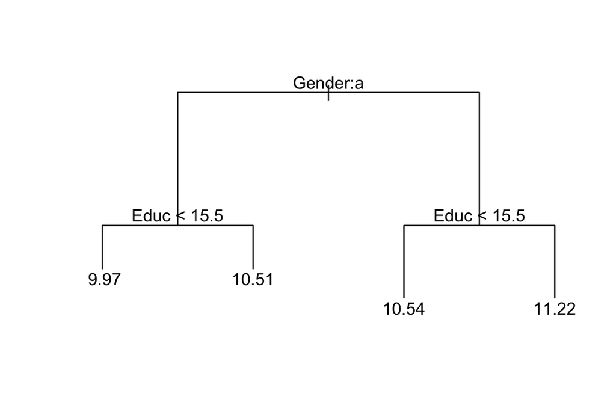

```
b) How many end nodes? Briefly explain how the estimation is obtained in each end nodes and describe the prediction equation
```

```
c) Does it show interaction effect of Gender and Educ over Income?
```

**Since Educ has a split after Gender, there is interaction effect of Gender and Educ over Income.**

```
d) Predict Michelle's income
```

**Michelle’s LogIncome is predicted to be 9.97.**

2. fit2: fit2 <- rpart(Income2005 ~., data.train, minsplit=20, cp=.009)
   1. Display the tree using plot(as.party(fit2), main=“Final Tree with Rpart”)

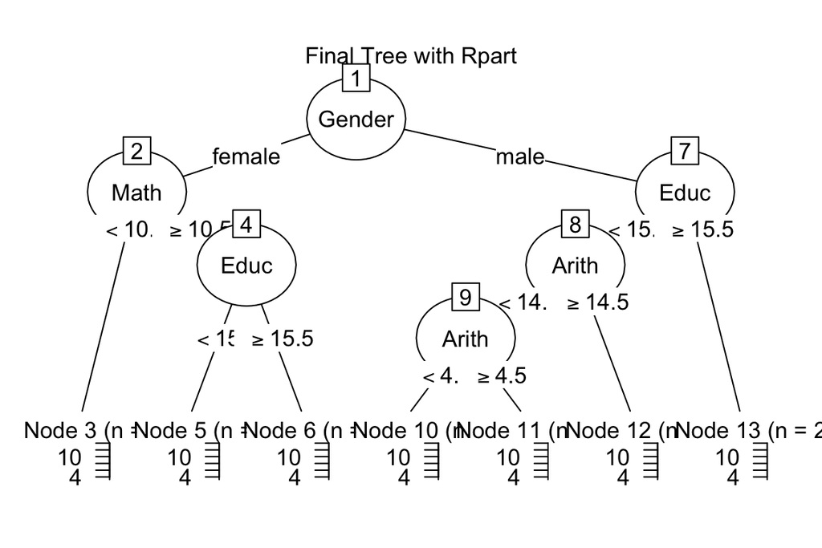

```
b) A brief summary of the fit2
```

**The model fit2 has seven end node, and this tree takes all of the predictor variables into consideration and splits only if there are at least 20 observations in a node. Out of all of the predictor variables, Gender has the greatest importance, hence it is the root of the tree. For example, if a person is male and has completed at least 15.5 years of Education, then his predicted LogIncome is 11.22.**

```
c) Compare testing errors between fit1 and fit2. Is the training error from fit2 always less than that from fit1? Is the testing error from fit2 always smaller than that from fit1?
```

**Since fit2 uses all of the predictor variables, we would expect its training error to be always less than that from fit1 because fit2 should provide a better fit to the training data. We can see that the training error for fit2 (0.7437005) is less than that of fit1 (0.7900584). However, we cannot expect the testing error of fit2 to be always less than that from fit1 because using more predictor variables doesn’t always result in a better model, and it is possible that fit2 overfits the training data, which can result in a higher testing error. As we can see, the testing error for fit2 (0.6823709) is also less than that of fit1 (0.7059736).**

```
d) You may prune the fit2 to get a tree with small testing error.
```

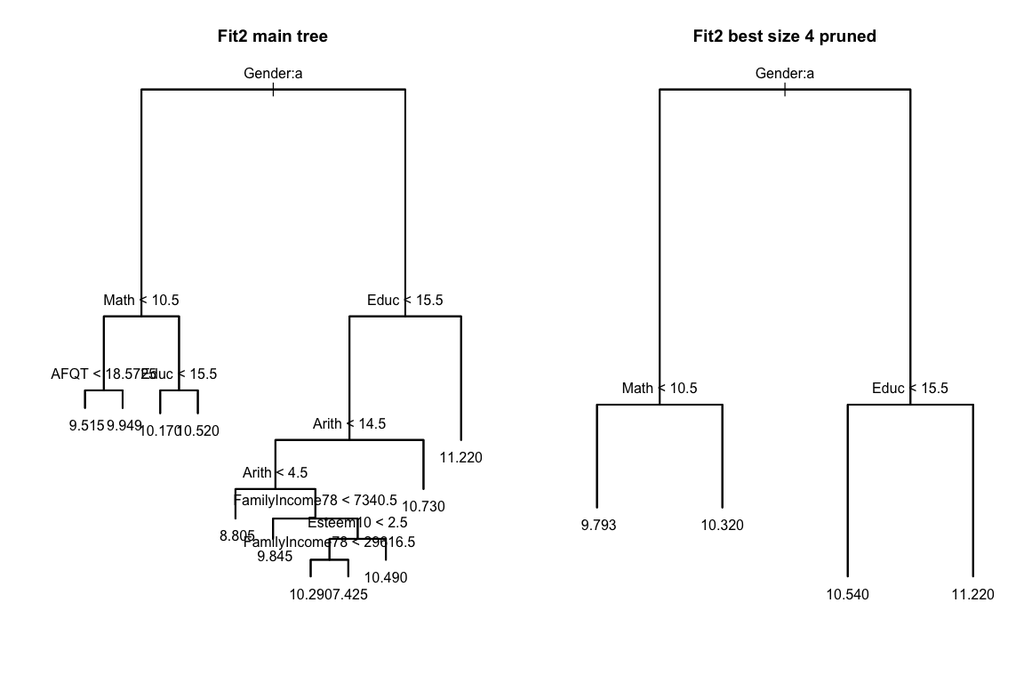

3. fit3: bag two trees

```
a) Take 2 bootstrap training samples and build two trees using the
rpart(Income2005 ~., data.train.b, minsplit=20, cp=.009). Display both trees.
```

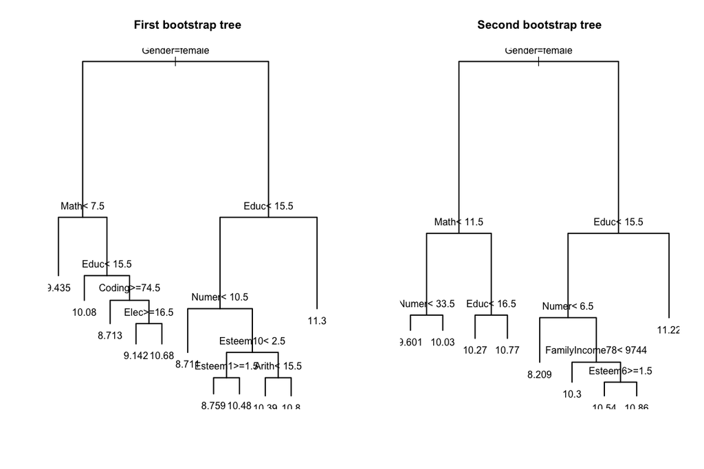

```
b) Explain how to get fitted values for Michelle by bagging the two trees obtained above. Do not use the predict().
```

**We can get fitted values for Michelle by taking the average of fitted equations from the two trees, and her fitted value is 9.84.**

```
c) What is the testing error for the bagged tree. Is it guaranteed that the testing error by bagging the two tree always smaller that either single tree?
```

**The testing error for the bagged tree is 0.7647221, and it is not guaranteed that the testing error by bagging the two tree always smaller that either single tree because if the single trees already have low variance and are well-tuned, bagging would not offer much benefit and could even increase the testing error.**

4. fit4: Build a best possible RandomForest
   1. Show the process how you tune mtry and number of trees. Give a very high level explanation how fit4 is built.

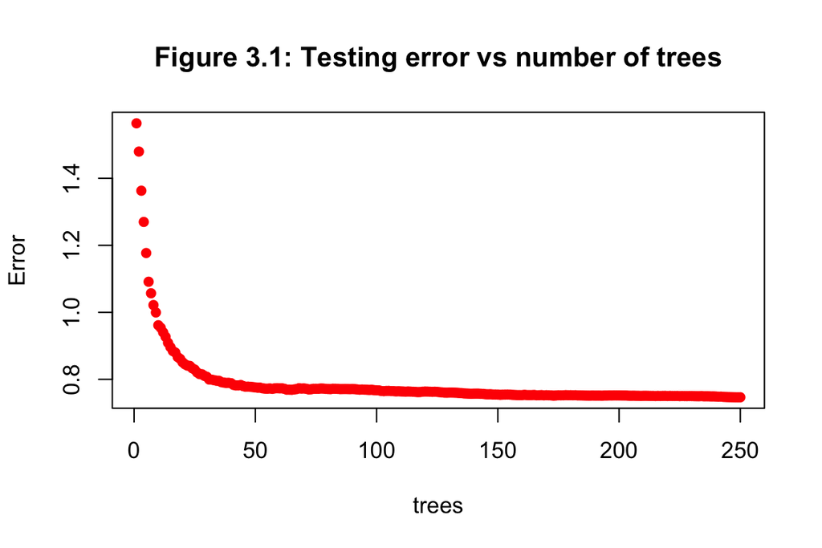

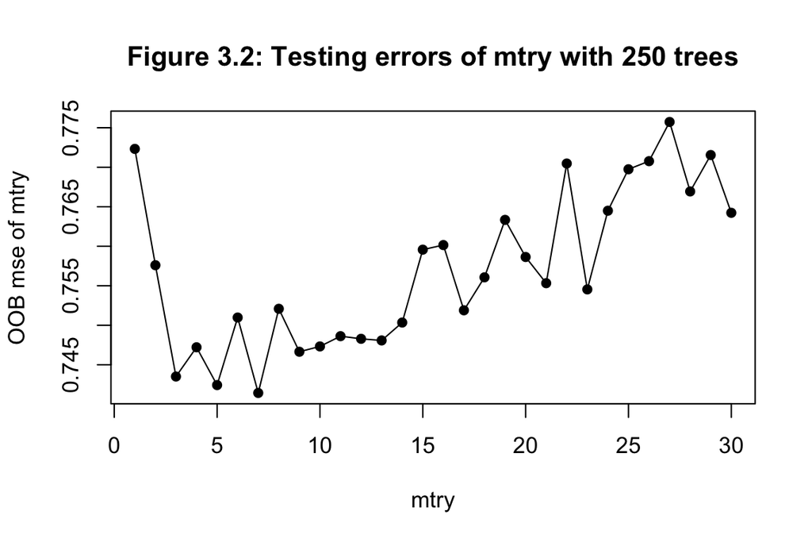

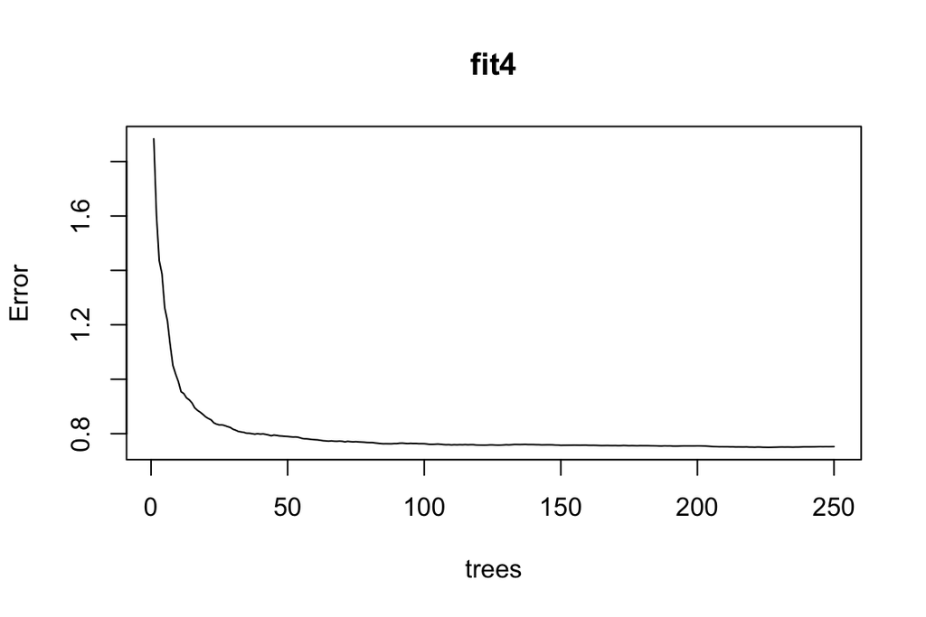

```
b) Compare the oob errors from fit4 to the testing errors using your testing data. Are you convinced that oob errors estimate testing error reasonably well.
```

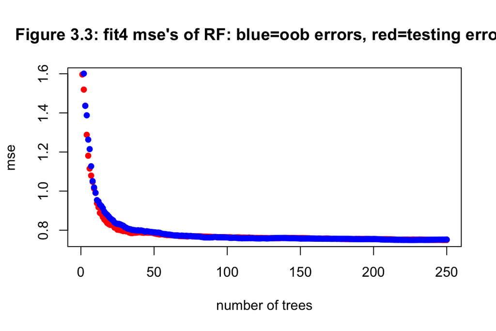

**As seem from Figure 3.3, the oob errors estimate testing errors pretty well.**

```
c) What is the predicted value for Michelle?
```

**The predicted LogIncome value for Michelle is 9.81.**

22. Now you have built so many predicted models (fit1 through fit4 in this section). What about build a fit5 which bags fit1 through fit4. Does fit5 have the smallest testing error?

**The testing error for fit5 is 0.7395131, which is not the smallest testing error as fit2 has the smallest testing error of 0.6823709 out of all of the models.**

6. Summarize the results and nail down one best possible final model you will recommend to predict income. Explain briefly why this is the best choice. Finally for the first time evaluate the prediction error using the validating data set.

**The best possible final model is fit2, which is just one tree that uses all of the predictor variables. This is because we are predicting LogIncome on Michelle, who is just one person, so out of all of the models, fit2 just turns out to be the one that predicts the best for her. If we are predicting on a larger group of people, then it is more likely that the bagged trees will have a lower testing error because there are more people in the sample for the trees to predict on. The validation error for fit2 is 0.8504427.**

7. Use your final model to predict Michelle’s income.